# R Notebook

```r
rm(list = setdiff(ls(), lsf.str()))

library(tidyverse)
library(caret)
library(testthat)
library(class)
library(MASS)
```

# 10

This question should be answered using the Weekly data set, which is part of the ISLR package. This data contains 1,089 weekly returns for 21 years, from the beginning of 1990 to the end of 2010.

```r
library(ISLR)
attach(Weekly)
```

## a

Produce some numerical and graphical summaries of the Weekly data. Do there appear to be any patterns?

```r
dim(Weekly)
```

```
## [1] 1089    9
```

```r
names(Weekly)
```

```
## [1] "Year"      "Lag1"      "Lag2"      "Lag3"      "Lag4"      "Lag5"
## [7] "Volume"    "Today"     "Direction"
```

```r
head(Weekly)
```

|  | Year | Lag1 | Lag2 | Lag3 | Lag4 | Lag5 | Volume | Today | Direction |
| --- | --- | --- | --- | --- | --- | --- | --- | --- | --- |
| 1 | 1990 | 0.816 | 1.572 | -3.936 | -0.229 | -3.484 | 0.1549760 | -0.270 | Down |
| 2 | 1990 | -0.270 | 0.816 | 1.572 | -3.936 | -0.229 | 0.1485740 | -2.576 | Down |
| 3 | 1990 | -2.576 | -0.270 | 0.816 | 1.572 | -3.936 | 0.1598375 | 3.514 | Up |
| 4 | 1990 | 3.514 | -2.576 | -0.270 | 0.816 | 1.572 | 0.1616300 | 0.712 | Up |
| 5 | 1990 | 0.712 | 3.514 | -2.576 | -0.270 | 0.816 | 0.1537280 | 1.178 | Up |
| 6 | 1990 | 1.178 | 0.712 | 3.514 | -2.576 | -0.270 | 0.1544440 | -1.372 | Down |

```r
summary(Weekly)
```

```
##       Year           Lag1               Lag2               Lag3
##  Min.   :1990   Min.   :-18.1950   Min.   :-18.1950   Min.   :-18.1950
##  1st Qu.:1995   1st Qu.: -1.1540   1st Qu.: -1.1540   1st Qu.: -1.1580
##  Median :2000   Median :  0.2410   Median :  0.2410   Median :  0.2410
##  Mean   :2000   Mean   :  0.1506   Mean   :  0.1511   Mean   :  0.1472
##  3rd Qu.:2005   3rd Qu.:  1.4050   3rd Qu.:  1.4090   3rd Qu.:  1.4090
##  Max.   :2010   Max.   : 12.0260   Max.   : 12.0260   Max.   : 12.0260
##       Lag4               Lag5              Volume
##  Min.   :-18.1950   Min.   :-18.1950   Min.   :0.08747
##  1st Qu.: -1.1580   1st Qu.: -1.1660   1st Qu.:0.33202
##  Median :  0.2380   Median :  0.2340   Median :1.00268
##  Mean   :  0.1458   Mean   :  0.1399   Mean   :1.57462
##  3rd Qu.:  1.4090   3rd Qu.:  1.4050   3rd Qu.:2.05373
##  Max.   : 12.0260   Max.   : 12.0260   Max.   :9.32821
##      Today          Direction
##  Min.   :-18.1950   Down:484
##  1st Qu.: -1.1540   Up  :605
##  Median :  0.2410
##  Mean   :  0.1499
##  3rd Qu.:  1.4050
##  Max.   : 12.0260
```

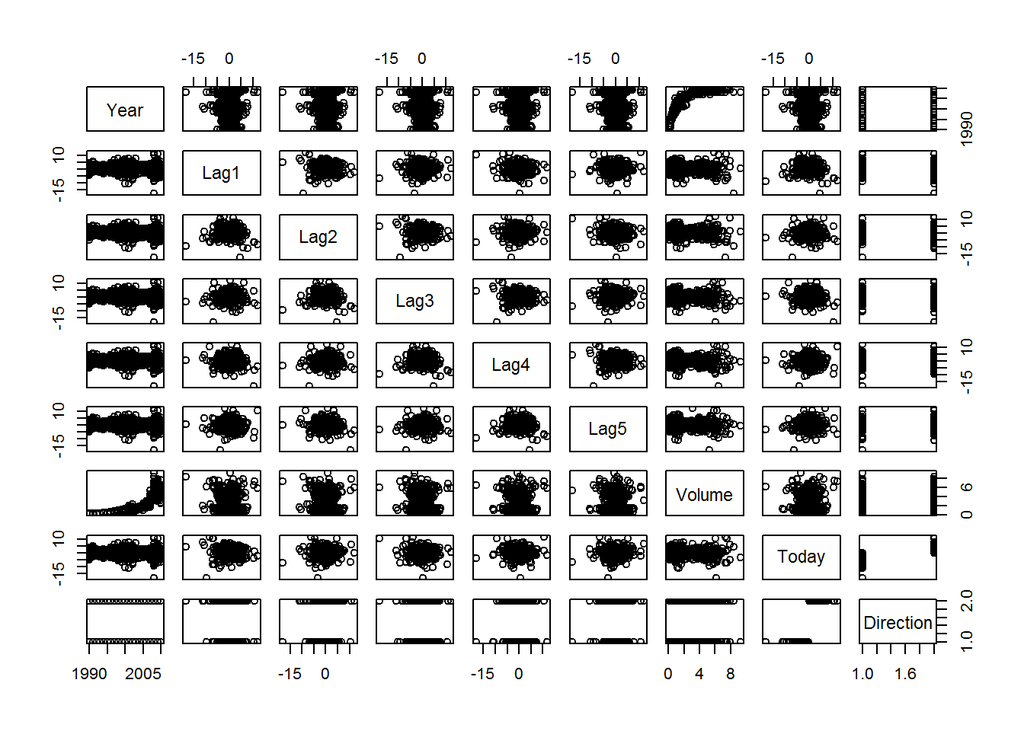

```r
plot(Weekly)
```

## b

Use the full data set to perform a logistic regression with Direction as the response and the five lag variables plus Volume as predictors. Use the summary function to print the results. Do any of the predictors appear to be statistically significant? If so, which ones?

```r
fit = glm(Direction ~ . -Year -Today, data = Weekly, family=binomial)
summary(fit)
```

```
##
## Call:
## glm(formula = Direction ~ . - Year - Today, family = binomial,
##     data = Weekly)
##
## Deviance Residuals:
##     Min       1Q   Median       3Q      Max
## -1.6949  -1.2565   0.9913   1.0849   1.4579
##
## Coefficients:
##             Estimate Std. Error z value Pr(>|z|)
## (Intercept)  0.26686    0.08593   3.106   0.0019 **
## Lag1        -0.04127    0.02641  -1.563   0.1181
## Lag2         0.05844    0.02686   2.175   0.0296 *
## Lag3        -0.01606    0.02666  -0.602   0.5469
## Lag4        -0.02779    0.02646  -1.050   0.2937
## Lag5        -0.01447    0.02638  -0.549   0.5833
## Volume      -0.02274    0.03690  -0.616   0.5377
## ---
## Signif. codes:  0 '***' 0.001 '**' 0.01 '*' 0.05 '.' 0.1 ' ' 1
##
## (Dispersion parameter for binomial family taken to be 1)
##
##     Null deviance: 1496.2  on 1088  degrees of freedom
## Residual deviance: 1486.4  on 1082  degrees of freedom
## AIC: 1500.4
##
## Number of Fisher Scoring iterations: 4
```

There is only one predictor that appears to be statistically significant: Lag2. We note that Lag2’s Z-value is 2.175 with an associated p-value of 0.03 which is less than 0.05. This leads us to reject the null hypothesis and declare that there is some relationship between one or more of the independent variables and the dependent variable. (Although I would argue that the relationship is rather weak…)

## c

Compute the confusion matrix and overall fraction of correct predictions. Explain what the confusion matrix is telling you about the types of mistakes made by logistic regression.

We can also examine the model’s prediction values. The `type="response"` option tells R to output probabilities of the form $P(Y = 1|X)$, as opposed to other information such as the logit. If no data set is supplied to the predict() function, then the probabilities are computed for the training data that was used to fit the logistic regression model.

```r
probs = predict(fit, type = 'response')
```

Since Direction is a qualitative variable we can examine the dummy values R has created for us:

```r
contrasts(Direction)
```

```
##      Up
## Down  0
## Up    1
```

Now we know that the values output from the `predict` function are the correspond to the probability of the market going up rather than down. Next, we can create a confusion matrix:

```r
# Create the vector of Direction predictions from the fitted model
preds = rep("Down", dim(Weekly)[1])
preds[probs > 0.5] = 'Up'

# Create the confusion matrix
{
  print(confusionMatrix(factor(preds), factor(Weekly$Direction))$table)
  print(confusionMatrix(factor(preds), factor(Weekly$Direction))$overall)
}
```

```
##           Reference
## Prediction Down  Up
##       Down   54  48
##       Up    430 557
##       Accuracy          Kappa  AccuracyLower  AccuracyUpper   AccuracyNull
##   5.610652e-01   3.499327e-02   5.310002e-01   5.907994e-01   5.555556e-01
## AccuracyPValue  McnemarPValue
##   3.690448e-01   5.189745e-68
```

The model predicts the direction of the market correctly 56% of the time. However, if we were to naively pick “Up” as the prediction for every observation we would have an accuracy rating of `605/(484+605) = 55.6%`. Thus the model only does slightly better than random guessing.

Next we can examine the ratio of correct to incorrect predictions for each Direction:

```
Pred      Down  Up
Down      54    48
Up        430   557

Correct:  11%   92%
```

Thus we see that the model is much better at predicting ‘Up’ movements (92% accuracy) than ‘Down’ movements (11% accuracy).

## d

Now fit the logistic regression model using a training data period from 1990 to 2008, with Lag2 as the only predictor. Compute the confusion matrix and the overall fraction of correct predictions for the held out data (that is, the data from 2009 and 2010).

```r
train = subset(Weekly, Year < 2009)
test = subset(Weekly, Year >= 2009)

assertthat::are_equal( (dim(train)[1] + dim(test)[1]), dim(Weekly)[1] )
```

```
## [1] TRUE
```

```r
# Fit the model on the training data
fit = glm(Direction ~ Lag2, data = train, family=binomial)

# Predict using the test data
probs = predict(fit, test, type = 'response')

preds = rep("Down", dim(test)[1])
preds[probs > 0.5] = 'Up'

# Create the confusion matrix
{
  print(confusionMatrix(factor(preds), factor(test$Direction))$table)
  print(confusionMatrix(factor(preds), factor(test$Direction))$overall)
}
```

```
##           Reference
## Prediction Down Up
##       Down    9  5
##       Up     34 56
##       Accuracy          Kappa  AccuracyLower  AccuracyUpper   AccuracyNull
##   6.250000e-01   1.414056e-01   5.246597e-01   7.180252e-01   5.865385e-01
## AccuracyPValue  McnemarPValue
##   2.439500e-01   7.339821e-06
```

The model has an accuracy rating of 62% which improves on the previous model by 6%. The model is also now 10% better at correctly predicting ‘Down’ movements:

```
Pred      Down  Up
Down      9     5
Up        34    56

Correct:  21%   92%
```

## e

Repeat (d) using LDA.

```r
# Fit the LDA model on the training data
fit = lda(Direction ~ + Lag2, data = train)

# Make predictions against the test data
pred = predict(fit, test)

# Confusion matrix and accuracy
{
  print(confusionMatrix(factor(pred$class), factor(test$Direction))$table)
  print(confusionMatrix(factor(pred$class), factor(test$Direction))$overall)
}
```

```
##           Reference
## Prediction Down Up
##       Down    9  5
##       Up     34 56
##       Accuracy          Kappa  AccuracyLower  AccuracyUpper   AccuracyNull
##   6.250000e-01   1.414056e-01   5.246597e-01   7.180252e-01   5.865385e-01
## AccuracyPValue  McnemarPValue
##   2.439500e-01   7.339821e-06
```

The LDA model has the same outcomes and results as the logistic regression model.

## f

Repeat (d) using QDA.

```r
# Fit the LDA model on the training data
fit = qda(Direction ~ + Lag2, data = train)

# Make predictions against the test data
pred = predict(fit, test)

# Confusion matrix and accuracy
{
  print(confusionMatrix(factor(pred$class), factor(test$Direction))$table)
  print(confusionMatrix(factor(pred$class), factor(test$Direction))$overall)
}
```

```
##           Reference
## Prediction Down Up
##       Down    0  0
##       Up     43 61
```

```
##       Accuracy          Kappa  AccuracyLower  AccuracyUpper   AccuracyNull
##   5.865385e-01   0.000000e+00   4.857634e-01   6.822542e-01   5.865385e-01
## AccuracyPValue  McnemarPValue
##   5.418874e-01   1.504286e-10
```

The QDA model has predicted ‘Up’ for every observation:

```r
assertthat::are_equal( length(pred$class == 'Up'), dim(test)[1] )
```

```
## [1] TRUE
```

This results in an accuracy of 59% for the model, which is less than the previous logistic regression and LDA models.

## g

Repeat (d) using KNN with K = 1.

Setup the argument objects required by the KNN function:

```r
ktrain = cbind(train$Lag2)
ktest =  cbind(test$Lag2)
klabels = train$Direction
```

Fit the model with K = 1:

```r
set.seed(1)
fit = knn(ktrain, ktest, klabels, k = 1)
```

Create a confusion matrix as we did with the LR, LDA and QDA models:

```r
{
  print(confusionMatrix(factor(fit), factor(test$Direction))$table)
  print(confusionMatrix(factor(fit), factor(test$Direction))$overall)
}
```

```
##           Reference
## Prediction Down Up
##       Down   21 30
##       Up     22 31
##       Accuracy          Kappa  AccuracyLower  AccuracyUpper   AccuracyNull
##    0.500000000   -0.003339518    0.400338925    0.599661075    0.586538462
## AccuracyPValue  McnemarPValue
##    0.970013136    0.331685068
```

The accuracy is only 50% for `K = 1`. Increasing `K` to 3:

```r
set.seed(1)
fit = knn(ktrain, ktest, klabels, k = 3)
{
  print(confusionMatrix(factor(fit), factor(test$Direction))$table)
  print(confusionMatrix(factor(fit), factor(test$Direction))$overall)
}
```

```
##           Reference
## Prediction Down Up
##       Down   16 20
##       Up     27 41
##       Accuracy          Kappa  AccuracyLower  AccuracyUpper   AccuracyNull
##      0.5480769      0.0453125      0.4474460      0.6458988      0.5865385
## AccuracyPValue  McnemarPValue
##      0.8151603      0.3814706
```

The accuracy has increased by 4.8%, but is still less than the LR, LDA and QDA models.

## h

Which of these methods appears to provide the best results on this data?

The LR and LDA models did the best and had the same performance, namely an accuracy rating of 62% with the following Up/Down prediction rates:

```
Pred      Down  Up
Down      9     5
Up        34    56

Correct:  21%   92%
```

# 11

In this problem, you will develop a model to predict whether a given car gets high or low gas mileage based on the Auto data set.

```r
attach(Auto)
dim(Auto)
```

```
## [1] 392   9
```

## a

Create a binary variable, mpg01, that contains a 1 if mpg contains a value above its median, and a 0 if mpg contains a value below its median.

```r
mpg01 = rep(0, dim(Auto)[1])
mpg01[Auto$mpg > median(Auto$mpg)] = 1
Auto = cbind(Auto, mpg01)
names(Auto)
```

```
##  [1] "mpg"          "cylinders"    "displacement" "horsepower"
##  [5] "weight"       "acceleration" "year"         "origin"
##  [9] "name"         "mpg01"
```

```r
head(Auto)
```

|  | mpg | cylinders | displacement | horsepower | weight | acceleration | year | origin | name | mpg01 |
| --- | --- | --- | --- | --- | --- | --- | --- | --- | --- | --- |
| 1 | 18 | 8 | 307 | 130 | 3504 | 12.0 | 70 | 1 | chevrolet chevelle malibu | 0 |
| 2 | 15 | 8 | 350 | 165 | 3693 | 11.5 | 70 | 1 | buick skylark 320 | 0 |
| 3 | 18 | 8 | 318 | 150 | 3436 | 11.0 | 70 | 1 | plymouth satellite | 0 |
| 4 | 16 | 8 | 304 | 150 | 3433 | 12.0 | 70 | 1 | amc rebel sst | 0 |
| 5 | 17 | 8 | 302 | 140 | 3449 | 10.5 | 70 | 1 | ford torino | 0 |
| 6 | 15 | 8 | 429 | 198 | 4341 | 10.0 | 70 | 1 | ford galaxie 500 | 0 |

## b

Explore the data graphically in order to investigate the association between mpg01 and the other features. Which of the other features seem most likely to be useful in predicting mpg01? Scatterplots and boxplots may be useful tools to answer this question. Describe your findings.

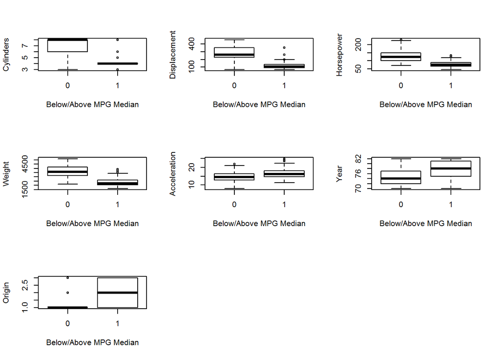

```r
{
  par(mfrow=c(3,3))
  boxplot(cylinders~mpg01,data=Auto, ylab="Cylinders", xlab="Below/Above MPG Median")
  boxplot(displacement~mpg01,data=Auto, ylab="Displacement", xlab="Below/Above MPG Median")
  boxplot(horsepower~mpg01,data=Auto, ylab="Horsepower", xlab="Below/Above MPG Median")
  boxplot(weight~mpg01,data=Auto, ylab="Weight", xlab="Below/Above MPG Median")
  boxplot(acceleration~mpg01,data=Auto, ylab="Acceleration", xlab="Below/Above MPG Median")
  boxplot(year~mpg01,data=Auto, ylab="Year", xlab="Below/Above MPG Median")
  boxplot(origin~mpg01,data=Auto, ylab="Origin", xlab="Below/Above MPG Median")
}
```

```r
cor(Auto[, -9])
```

```
##                     mpg  cylinders displacement horsepower     weight
## mpg           1.0000000 -0.7776175   -0.8051269 -0.7784268 -0.8322442
## cylinders    -0.7776175  1.0000000    0.9508233  0.8429834  0.8975273
## displacement -0.8051269  0.9508233    1.0000000  0.8972570  0.9329944
## horsepower   -0.7784268  0.8429834    0.8972570  1.0000000  0.8645377
## weight       -0.8322442  0.8975273    0.9329944  0.8645377  1.0000000
## acceleration  0.4233285 -0.5046834   -0.5438005 -0.6891955 -0.4168392
## year          0.5805410 -0.3456474   -0.3698552 -0.4163615 -0.3091199
## origin        0.5652088 -0.5689316   -0.6145351 -0.4551715 -0.5850054
## mpg01         0.8369392 -0.7591939   -0.7534766 -0.6670526 -0.7577566
##              acceleration       year     origin      mpg01
## mpg             0.4233285  0.5805410  0.5652088  0.8369392
## cylinders      -0.5046834 -0.3456474 -0.5689316 -0.7591939
## displacement   -0.5438005 -0.3698552 -0.6145351 -0.7534766
## horsepower     -0.6891955 -0.4163615 -0.4551715 -0.6670526
## weight         -0.4168392 -0.3091199 -0.5850054 -0.7577566
## acceleration    1.0000000  0.2903161  0.2127458  0.3468215
## year            0.2903161  1.0000000  0.1815277  0.4299042
## origin          0.2127458  0.1815277  1.0000000  0.5136984
## mpg01           0.3468215  0.4299042  0.5136984  1.0000000
```

It appears that cylinders, displacement, horsepower, and weight may be useful variables to predict mpg01.

## c

Split the data into a training set and a test set.

```r
# Randomly select 20% of the data to be the test set.  Note that most of the high MPG observations seem to be near the end of the data set, thus we need to use the 'sample' function.
set.seed(1)
index = sample(1:nrow(Auto), 0.2 * nrow(Auto), replace = F)

train = Auto[-index, ]
test = Auto[index,]
```

## d

Perform LDA on the training data in order to predict mpg01 using the variables that seemed most associated with mpg01 in (b). What is the test error of the model obtained?

```r
# Fit the LDA model on the training data
fit = lda(mpg01 ~ +cylinders +displacement +horsepower +weight, data = train)

# Make predictions against the test data
pred = predict(fit, test)

# Confusion matrix and accuracy
{
  print(confusionMatrix(factor(pred$class), factor(test$mpg01))$table)
  print(confusionMatrix(factor(pred$class), factor(test$mpg01))$overall)
  print(mean(factor(pred$class) != factor(test$mpg01)))
}
```

```
##           Reference
## Prediction  0  1
##          0 34  3
##          1  7 34
##       Accuracy          Kappa  AccuracyLower  AccuracyUpper   AccuracyNull
##   8.717949e-01   7.442623e-01   7.768379e-01   9.367723e-01   5.256410e-01
## AccuracyPValue  McnemarPValue
##   8.751052e-11   3.427817e-01
## [1] 0.1282051
```

The model has a 12.8% test error rate. It’s also somewhat worse at predicting autos whose MPG will be below the median than those that are above:

```
Pred      Down  Up
Down      34    3
Up        7     34

Correct:  83%   92%
```

## e

Perform QDA on the training data in order to predict mpg01 using the variables that seemed most associated with mpg01 in (b). What is the test error of the model obtained?

```r
rm(list = c('fit', 'probs', 'preds', 'pred'))

# Fit the LDA model on the training data
fit = qda(mpg01 ~ +cylinders +displacement +horsepower +weight, data = train)

# Make predictions against the test data
pred = predict(fit, test)

# Confusion matrix and accuracy
{
  print(confusionMatrix(factor(pred$class), factor(test$mpg01))$table)
  print(confusionMatrix(factor(pred$class), factor(test$mpg01))$overall)
  print(mean(factor(pred$class) != factor(test$mpg01)))
}
```

```
##           Reference
## Prediction  0  1
##          0 36  3
##          1  5 34
##       Accuracy          Kappa  AccuracyLower  AccuracyUpper   AccuracyNull
##   8.974359e-01   7.948718e-01   8.078725e-01   9.546691e-01   5.256410e-01
## AccuracyPValue  McnemarPValue
##   1.922888e-12   7.236736e-01
## [1] 0.1025641
```

The QDA is able to predict median MPG with an error rate of 10.3%, which is 2.5% less than the LDA model. The QDA model is also able to better predict both types of classifications evenly:

```
Pred      Down  Up
Down      36    3
Up        5     34

Correct:  88%   92%
```

## f

Perform logistic regression on the training data in order to predict mpg01 using the variables that seemed most associated with mpg01 in (b). What is the test error of the model obtained?

```r
rm(list = c('fit', 'probs', 'preds', 'pred'))
# Fit the model on the training data
fit = glm(mpg01 ~ +cylinders +displacement +horsepower +weight, data = train, family=binomial)

# Predict using the test data
probs = predict(fit, test, type = 'response')

preds = rep(0, dim(test)[1])
preds[probs > 0.5] = 1

# Create the confusion matrix
{
  print(confusionMatrix(factor(preds), factor(test$mpg01))$table)
  print(confusionMatrix(factor(preds), factor(test$mpg01))$overall)
  print(mean(factor(preds) != factor(test$mpg01)))
}
```

```
##           Reference
## Prediction  0  1
##          0 36  3
##          1  5 34
##       Accuracy          Kappa  AccuracyLower  AccuracyUpper   AccuracyNull
##   8.974359e-01   7.948718e-01   8.078725e-01   9.546691e-01   5.256410e-01
## AccuracyPValue  McnemarPValue
##   1.922888e-12   7.236736e-01
## [1] 0.1025641
```

The LR and QDA models appear to give the same outputs.

## g

Perform KNN on the training data, with several values of K, in order to predict mpg01. Use only the variables that seemed most associated with mpg01 in (b). What test errors do you obtain? Which value of K seems to perform the best on this data set?

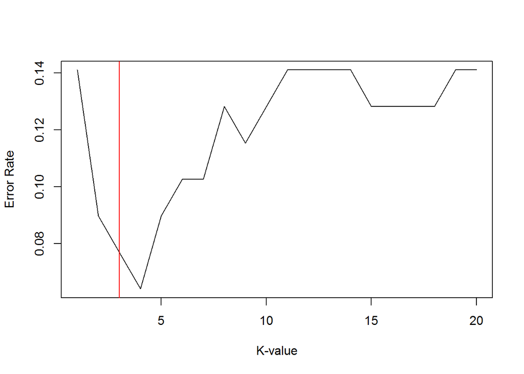

```r
preds = sapply(1:20,function(x){
    pred = knn(train[,c('cylinders', 'horsepower','weight','displacement')],
               test[,c('cylinders', 'horsepower','weight','displacement')],
               cl = train[,'mpg01'],
               k=x
           )
    mean(pred != test[,'mpg01'])
})

{
  plot(1:20, preds, type = 'l', xlab = "K-value", ylab = "Error Rate")
  abline(v = 3, col = 'red')
}
```

```r
min(preds)
```

```
## [1] 0.06410256
```

```r
preds = knn(train[,c('cylinders', 'horsepower','weight','displacement')],
            test[,c('cylinders', 'horsepower','weight','displacement')],
            cl = train[,'mpg01'],
            k=3
        )

# Create the confusion matrix
{
  print(confusionMatrix(factor(preds), factor(test$mpg01))$table)
}
```

```
##           Reference
## Prediction  0  1
##          0 37  2
##          1  4 35
```

```
Pred      Down  Up
Down      37    2
Up        4     35

Correct:  90%   95%
```

# 12

## a

Write a function, Power(), that prints out the result of raising 2 to the 3rd power. In other words, your function should compute 2^3 and print out the results.

```r
Power2 = function(a, x) {
  print(2^3)
}

Power2()
```

```
## [1] 8
```

## b

Create a new function, Power2(), that allows you to pass any two numbers, x and a, and prints out the value of x^a.

```r
Power2 = function(a, x) {
  print(a^x)
}

Power2(2, 3)
```

```
## [1] 8
```

Using the Power2() function that you just wrote, compute 10^3, 8^17, and 131^3.

```r
{
Power2(10, 3)
Power2(8, 17)
Power2(131, 3)
}
```

```
## [1] 1000
## [1] 2.2518e+15
## [1] 2248091
```

## d

Now create a new function, Power3(), that actually returns the result x^a as an R object, rather than simply printing it to the screen.

```r
Power3 = function(x, a) {
  result = x^a
  return(result)
}

x = Power3(2, 3);x
```

```
## [1] 8
```

## e

Now using the Power3() function, create a plot of f(x) = x2. The x-axis should display a range of integers from 1 to 10, and the y-axis should display x^2.

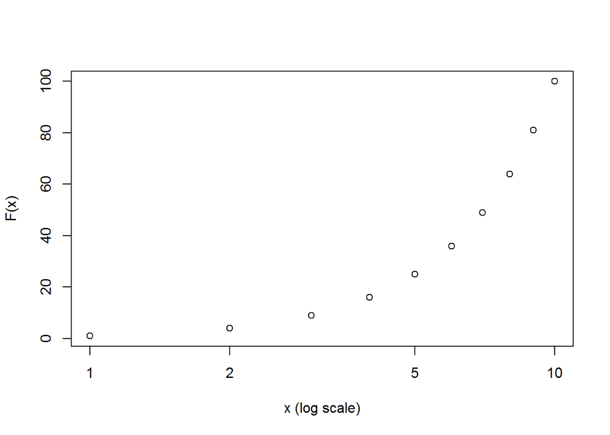

```r
x = seq(1, 10)
y = sapply(x, Power3, a = 2)

plot(x = x, y = y, xlab = 'x (log scale)', ylab = 'F(x)', log = 'x')
```

## f

Create a function, PlotPower(), that allows you to create a plot of x against x^a for a fixed a and for a range of values of x.

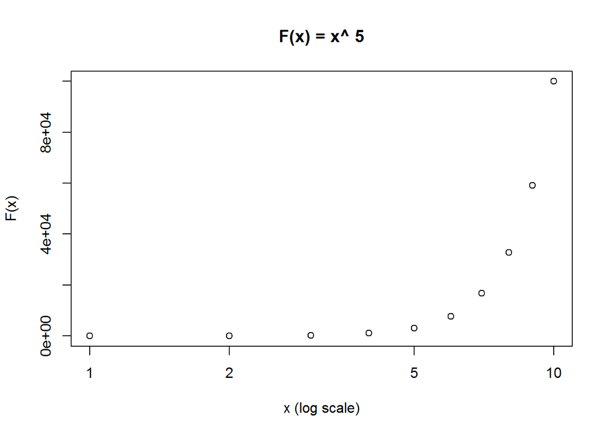

```r
PlotPower = function(x, a) {
  y = sapply(x, Power3, a = a)
  plot(
    x = x,
    y = y,
    main = paste("F(x) = x^", a),
    xlab = 'x (log scale)',
    ylab = 'F(x)', log = 'x')
  }

PlotPower(1:10, 5)
```

# 13

Using the Boston data set, fit classification models in order to predict whether a given suburb has a crime rate above or below the median. Explore logistic regression, LDA, and KNN models using various subsets of the predictors. Describe your findings.

## Create Helper Functions

```r
ShowStats = function(model, testData) {
  # Predict using the test data
  probs = predict(model, testData, type = 'response')

  # Create binary predictions
  preds = rep(0, dim(testData)[1])
  preds[probs > 0.5] = 1

  # Create the confusion matrix
  print(confusionMatrix(factor(preds), factor(testData$crim_med)))
}
```

## Create Response Variable

First create a binary response variable, crim_med, that contains a 1 if the crim value is above the median, and a 0 if crim is below or equal to the median.

```r
rm(Boston)
attach(Boston)
crim_med = rep(0, dim(Boston)[1])
crim_med[Boston$crim > median(Boston$crim)] = 1
Boston = cbind(Boston, crim_med)
names(Boston)
```

```
##  [1] "crim"     "zn"       "indus"    "chas"     "nox"      "rm"
##  [7] "age"      "dis"      "rad"      "tax"      "ptratio"  "black"
## [13] "lstat"    "medv"     "crim_med"
```

```r
head(Boston)
```

|  | crim | zn | indus | chas | nox | rm | age | dis | rad | tax | ptratio | black | lstat | medv | crim_med |
| --- | --- | --- | --- | --- | --- | --- | --- | --- | --- | --- | --- | --- | --- | --- | --- |
| 1 | 0.00632 | 18 | 2.31 | 0 | 0.538 | 6.575 | 65.2 | 4.0900 | 1 | 296 | 15.3 | 396.90 | 4.98 | 24.0 | 0 |
| 2 | 0.02731 | 0 | 7.07 | 0 | 0.469 | 6.421 | 78.9 | 4.9671 | 2 | 242 | 17.8 | 396.90 | 9.14 | 21.6 | 0 |
| 3 | 0.02729 | 0 | 7.07 | 0 | 0.469 | 7.185 | 61.1 | 4.9671 | 2 | 242 | 17.8 | 392.83 | 4.03 | 34.7 | 0 |
| 4 | 0.03237 | 0 | 2.18 | 0 | 0.458 | 6.998 | 45.8 | 6.0622 | 3 | 222 | 18.7 | 394.63 | 2.94 | 33.4 | 0 |
| 5 | 0.06905 | 0 | 2.18 | 0 | 0.458 | 7.147 | 54.2 | 6.0622 | 3 | 222 | 18.7 | 396.90 | 5.33 | 36.2 | 0 |
| 6 | 0.02985 | 0 | 2.18 | 0 | 0.458 | 6.430 | 58.7 | 6.0622 | 3 | 222 | 18.7 | 394.12 | 5.21 | 28.7 | 0 |

## Select Statisticly Signifgant Predictors

The statistically significant predictors should be selected next. Two selection methods will be utilized: Inspection of the model’s summary, and the MASS::stepAIC function:

**GLM Summary Inspection**

```r
fit = glm(crim_med ~ . -crim -crim_med, data = Boston, family=binomial)
summary(fit)
```

```
##
## Call:
## glm(formula = crim_med ~ . - crim - crim_med, family = binomial,
##     data = Boston)
##
## Deviance Residuals:
##     Min       1Q   Median       3Q      Max
## -2.3946  -0.1585  -0.0004   0.0023   3.4239
##
## Coefficients:
##               Estimate Std. Error z value Pr(>|z|)
## (Intercept) -34.103704   6.530014  -5.223 1.76e-07 ***
## zn           -0.079918   0.033731  -2.369  0.01782 *
## indus        -0.059389   0.043722  -1.358  0.17436
## chas          0.785327   0.728930   1.077  0.28132
## nox          48.523782   7.396497   6.560 5.37e-11 ***
## rm           -0.425596   0.701104  -0.607  0.54383
## age           0.022172   0.012221   1.814  0.06963 .
## dis           0.691400   0.218308   3.167  0.00154 **
## rad           0.656465   0.152452   4.306 1.66e-05 ***
## tax          -0.006412   0.002689  -2.385  0.01709 *
## ptratio       0.368716   0.122136   3.019  0.00254 **
## black        -0.013524   0.006536  -2.069  0.03853 *
## lstat         0.043862   0.048981   0.895  0.37052
## medv          0.167130   0.066940   2.497  0.01254 *
## ---
## Signif. codes:  0 '***' 0.001 '**' 0.01 '*' 0.05 '.' 0.1 ' ' 1
##
## (Dispersion parameter for binomial family taken to be 1)
##
##     Null deviance: 701.46  on 505  degrees of freedom
## Residual deviance: 211.93  on 492  degrees of freedom
## AIC: 239.93
##
## Number of Fisher Scoring iterations: 9
```

**MASS::stepAIC**

```r
fit = glm(crim_med ~ . -crim -crim_med, data = Boston, family=binomial)
step =  stepAIC(fit, direction="both")
```

```
## Start:  AIC=239.93
## crim_med ~ (crim + zn + indus + chas + nox + rm + age + dis +
##     rad + tax + ptratio + black + lstat + medv) - crim - crim_med
##
##           Df Deviance    AIC
## - rm       1   212.30 238.30
## - lstat    1   212.72 238.72
## - chas     1   213.09 239.09
## - indus    1   213.85 239.85
## <none>         211.93 239.93
## - age      1   215.37 241.37
## - tax      1   218.07 244.07
## - black    1   218.75 244.75
## - medv     1   218.82 244.82
## - zn       1   219.68 245.68
## - ptratio  1   221.91 247.91
## - dis      1   223.27 249.27
## - rad      1   252.03 278.02
## - nox      1   288.81 314.81
##
## Step:  AIC=238.3
## crim_med ~ zn + indus + chas + nox + age + dis + rad + tax +
##     ptratio + black + lstat + medv
##
##           Df Deviance    AIC
## - chas     1   213.48 237.48
## - lstat    1   213.76 237.76
## - indus    1   214.23 238.23
## <none>         212.30 238.30
## - age      1   215.53 239.53
## + rm       1   211.93 239.93
## - tax      1   218.72 242.72
## - black    1   218.91 242.91
## - zn       1   220.51 244.51
## - ptratio  1   222.20 246.20
## - dis      1   223.27 247.27
## - medv     1   225.22 249.22
## - rad      1   252.22 276.22
## - nox      1   288.90 312.90
##
```

[output cut: 44 more lines]

```
##           Df Deviance    AIC
## <none>         216.22 236.22
## + lstat    1   214.95 236.95
## + chas     1   215.19 237.19
## + rm       1   215.23 237.23
## + indus    1   215.28 237.28
## - age      1   221.78 239.78
## - black    1   222.52 240.52
## - ptratio  1   224.30 242.30
## - zn       1   225.78 243.78
## - dis      1   226.54 244.54
## - tax      1   227.52 245.52
## - medv     1   228.87 246.87
## - rad      1   267.04 285.04
## - nox      1   294.55 312.55
```

```r
step$anova # display results
```

| Step | Df | Deviance | Resid. Df | Resid. Dev | AIC |
| --- | --- | --- | --- | --- | --- |
|  | NA | NA | 492 | 211.9270 | 239.9270 |
| - rm | 1 | 0.3689902 | 493 | 212.2960 | 238.2960 |
| - chas | 1 | 1.1846341 | 494 | 213.4806 | 237.4806 |
| - indus | 1 | 1.4716157 | 495 | 214.9523 | 236.9523 |
| - lstat | 1 | 1.2638910 | 496 | 216.2162 | 236.2162 |

The MASS::stepAIC also indicated that the variables indus, chas, rm, and lstat should be removed from the model.

## Create Training and Test Datasets

Split the data into a training set and a test set.

```r
# Randomly select 20% of the data to be the test set using the 'sample' function.
set.seed(1)
index = sample(1:nrow(Boston), 0.2 * nrow(Boston), replace = F)

train = Boston[-index, ]
test = Boston[index,]
```

## Logistic Regression Model

Fit a logistic regression model with the predictors determined to be statistically significant:

```r
fit = glm(crim_med ~ zn + nox + age + dis + rad + tax + ptratio + black + medv, data = train, family=binomial)
ShowStats(fit, test)
```

```
## Confusion Matrix and Statistics
##
##           Reference
## Prediction  0  1
##          0 42  6
##          1  9 44
##
##                Accuracy : 0.8515
##                  95% CI : (0.7669, 0.9144)
##     No Information Rate : 0.505
##     P-Value [Acc > NIR] : 2.852e-13
##
##                   Kappa : 0.7031
##  Mcnemar's Test P-Value : 0.6056
##
##             Sensitivity : 0.8235
##             Specificity : 0.8800
##          Pos Pred Value : 0.8750
##          Neg Pred Value : 0.8302
##              Prevalence : 0.5050
##          Detection Rate : 0.4158
##    Detection Prevalence : 0.4752
##       Balanced Accuracy : 0.8518
##
##        'Positive' Class : 0
##
```

## LDA

```r
# Fit the LDA model on the training data
fit = lda(crim_med ~ zn + nox + age + dis + rad + tax + ptratio + black + medv, data = train)

# Make predictions against the test data
pred = predict(fit, test)

# Confusion matrix and accuracy
print(confusionMatrix(factor(pred$class), factor(test$crim_med)))
```

```
## Confusion Matrix and Statistics
##
##           Reference
## Prediction  0  1
##          0 48  9
##          1  3 41
##
##                Accuracy : 0.8812
##                  95% CI : (0.8017, 0.9371)
##     No Information Rate : 0.505
##     P-Value [Acc > NIR] : 1.158e-15
##
##                   Kappa : 0.7621
##  Mcnemar's Test P-Value : 0.1489
##
##             Sensitivity : 0.9412
##             Specificity : 0.8200
##          Pos Pred Value : 0.8421
##          Neg Pred Value : 0.9318
##              Prevalence : 0.5050
##          Detection Rate : 0.4752
##    Detection Prevalence : 0.5644
##       Balanced Accuracy : 0.8806
##
##        'Positive' Class : 0
##
```

## QDA

```r
# Fit the LDA model on the training data
fit = qda(crim_med ~ zn + nox + age + dis + rad + tax + ptratio + black + medv, data = train)

# Make predictions against the test data
pred = predict(fit, test)

# Confusion matrix and accuracy
print(confusionMatrix(factor(pred$class), factor(test$crim_med)))
```

```
## Confusion Matrix and Statistics
##
##           Reference
## Prediction  0  1
##          0 50 11
##          1  1 39
##
##                Accuracy : 0.8812
##                  95% CI : (0.8017, 0.9371)
##     No Information Rate : 0.505
##     P-Value [Acc > NIR] : 1.158e-15
##
##                   Kappa : 0.7619
##  Mcnemar's Test P-Value : 0.009375
##
##             Sensitivity : 0.9804
##             Specificity : 0.7800
##          Pos Pred Value : 0.8197
##          Neg Pred Value : 0.9750
##              Prevalence : 0.5050
##          Detection Rate : 0.4950
##    Detection Prevalence : 0.6040
##       Balanced Accuracy : 0.8802
##
##        'Positive' Class : 0
##
```

## KNN

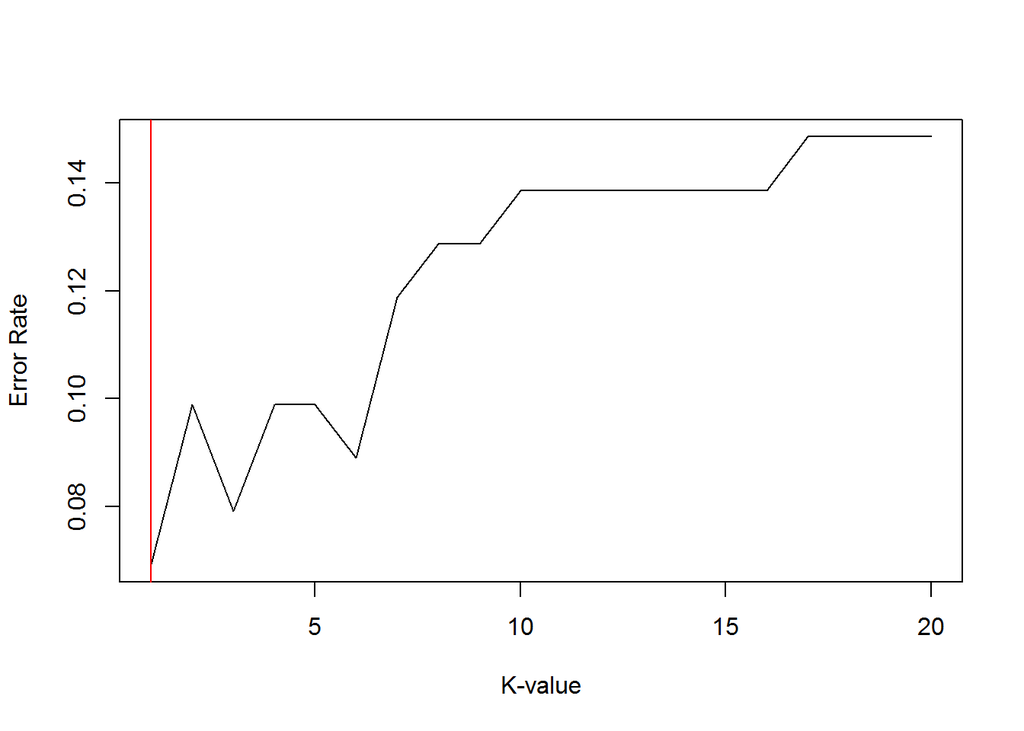

```r
preds = sapply(1:20,function(x){
    pred = knn(train[,c('zn', 'nox', 'age', 'dis', 'rad', 'tax', 'ptratio', 'black', 'medv')],
               test[,c('zn', 'nox', 'age', 'dis', 'rad', 'tax', 'ptratio', 'black', 'medv')],
               cl = train[,'crim_med'],
               k=x
           )
    mean(pred != test[,'crim_med'])
})

{
  plot(1:20, preds, type = 'l', xlab = "K-value", ylab = "Error Rate")
  abline(v = 1, col = 'red')
}
```

```r
min(preds)
```

```
## [1] 0.06930693
```

```r
preds = knn(train[,c('zn', 'nox', 'age', 'dis', 'rad', 'tax', 'ptratio', 'black', 'medv')],
            test[,c('zn', 'nox', 'age', 'dis', 'rad', 'tax', 'ptratio', 'black', 'medv')],
            cl = train[,'crim_med'],
            k=1
        )

# Create the confusion matrix
confusionMatrix(factor(preds), factor(test$crim_med))
```

```
## Confusion Matrix and Statistics
##
##           Reference
## Prediction  0  1
##          0 47  3
##          1  4 47
##
##                Accuracy : 0.9307
##                  95% CI : (0.8624, 0.9717)
##     No Information Rate : 0.505
##     P-Value [Acc > NIR] : <2e-16
##
##                   Kappa : 0.8614
##  Mcnemar's Test P-Value : 1
##
##             Sensitivity : 0.9216
##             Specificity : 0.9400
##          Pos Pred Value : 0.9400
##          Neg Pred Value : 0.9216
##              Prevalence : 0.5050
##          Detection Rate : 0.4653
##    Detection Prevalence : 0.4950
##       Balanced Accuracy : 0.9308
##
##        'Positive' Class : 0
##
```

## Conclusion

The KNN model with K = 1 by far did the best. This also makes sense, because houses are geographically clustered together. Thus it would be safe to assume that if a given house was in a low crime area then so too would be the other houses nearby and visa versa for high crime areas.